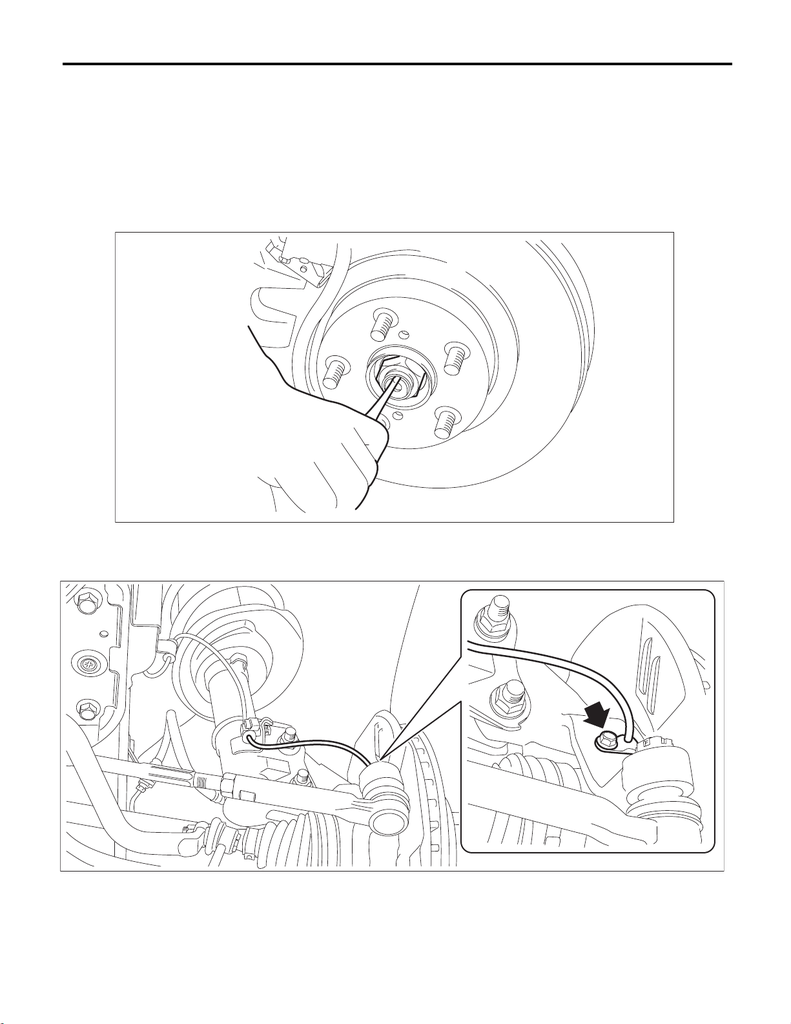

DS-25

Front Hub Unit Bearing

DRIVE SHAFT SYSTEM

4. Front Hub Unit Bearing

A: REMOVAL

1) Lift up the vehicle, and then remove the front wheels.

2) Remove the nut - axle.

CAUTION:

Do not loosen the nut - axle while the front axle is loaded. Doing so may damage the hub unit COMPL.

(1) Lift the crimped section of the nut - axle.

(2) Remove the nut - axle using a socket wrench while depressing the brake pedal.

3) Remove the disc brake assembly. <Ref. to BR-25, REMOVAL, Front Disc Brake Assembly.>

4) Remove the disc rotor. <Ref. to BR-22, REMOVAL, Front Disc Rotor.>

5) Remove the bolts, and remove the front ABS wheel speed sensor.

DS-00486

DS-00604

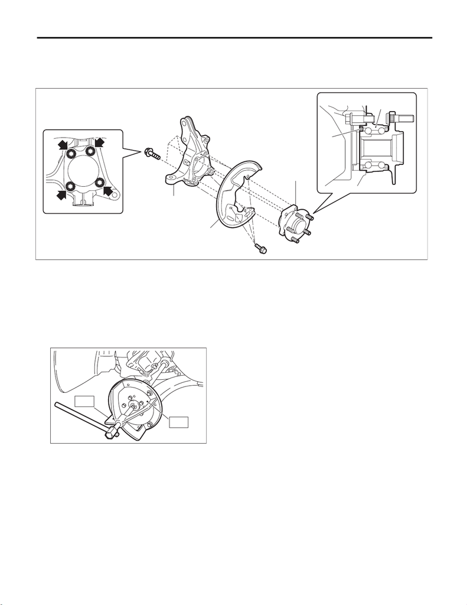

DS-26

Front Hub Unit Bearing

DRIVE SHAFT SYSTEM

6) Remove the hub unit COMPL - front axle.

CAUTION:

• Do not get closer the tool which charged magnetism to magnetic encoder.

• Be careful not to damage the magnetic encoder.

NOTE:

If it is hard to remove, use the ST.

Preparation tool:

ST1: AXLE SHAFT PULLER (926470000)

ST2: AXLE SHAFT PULLER PLATE (28099PA110)

(a) Housing ASSY - front axle (c) Hub unit COMPL - front axle (d) Magnetic encoder

(b) Back plate - front brake

DS-00578

(a)

(b)

(c)

(c)

(d)

DS-00145

ST2

ST1

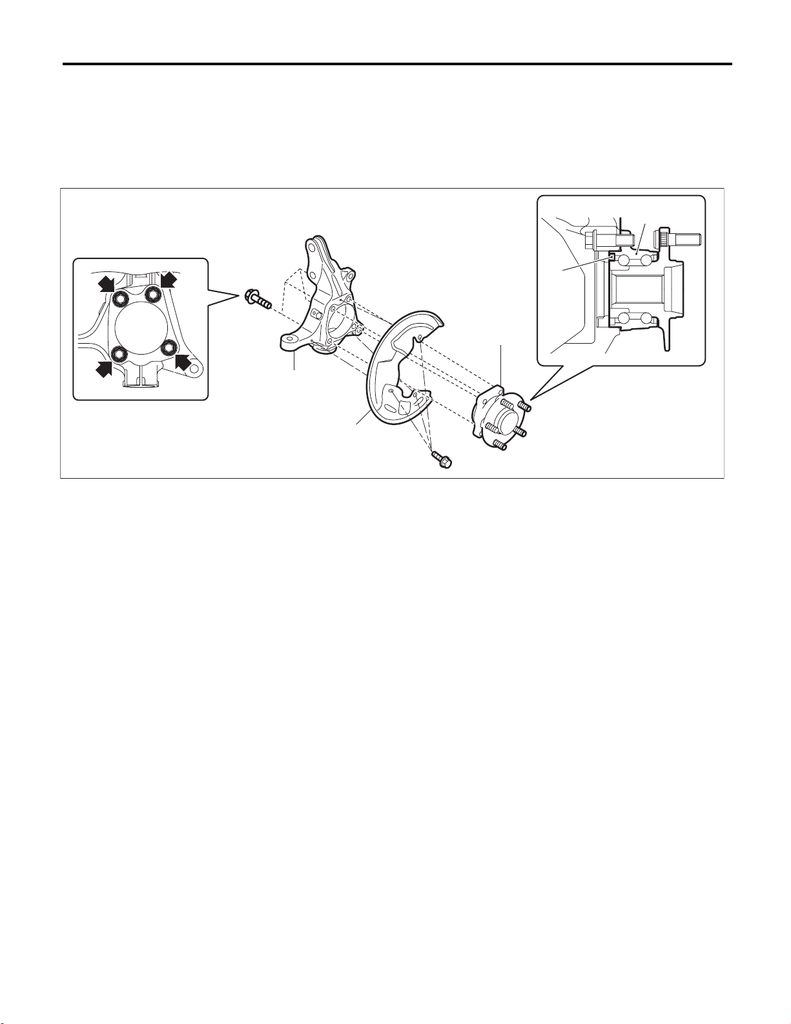

DS-27

Front Hub Unit Bearing

DRIVE SHAFT SYSTEM

B: INSTALLATION

1) Tighten the back plate - front brake and the hub unit COMPL - front axle to the housing assembly - front

axle with bolts.

CAUTION:

• Do not get closer the tool which charged magnetism to magnetic encoder.

• Be careful not to damage the magnetic encoder.

Tightening torque:

Back plate - front brake: 18 N·m (1.8 kgf-m, 13.3 ft-lb)

Hub unit COMPL - front axle: 65 N·m (6.6 kgf-m, 47.9 ft-lb)

2) Install the front drive shaft assembly.

CAUTION:

• Do not hammer the drive shaft assembly when installing.

• Use new nut - axle.

(1) Insert the drive shaft assembly into the hub spline, and pull it into the specified position.

(2) Tighten the new nut - axle temporarily.

3) Install the disc rotor to the hub unit COMPL - front axle.

4) Install the disc brake assembly to the housing assembly - front axle.

Tightening torque:

STI model: 155 N·m (15.8 kgf-m, 114.3 ft-lb)

Except for STI model: 80 N·m (8.2 kgf-m, 59.0 ft-lb)

5) Install the brake hose bracket.

Tightening torque:

33 N·m (3.4 kgf-m, 24.3 ft-lb)

6) Install the front ABS wheel speed sensor.

Tightening torque:

7.5 N·m (0.8 kgf-m, 5.5 ft-lb)

(a) Housing ASSY - front axle (c) Hub unit COMPL - front axle (d) Magnetic encoder

(b) Back plate - front brake

DS-00578

(a)

(b)

(c)

(c)

(d)

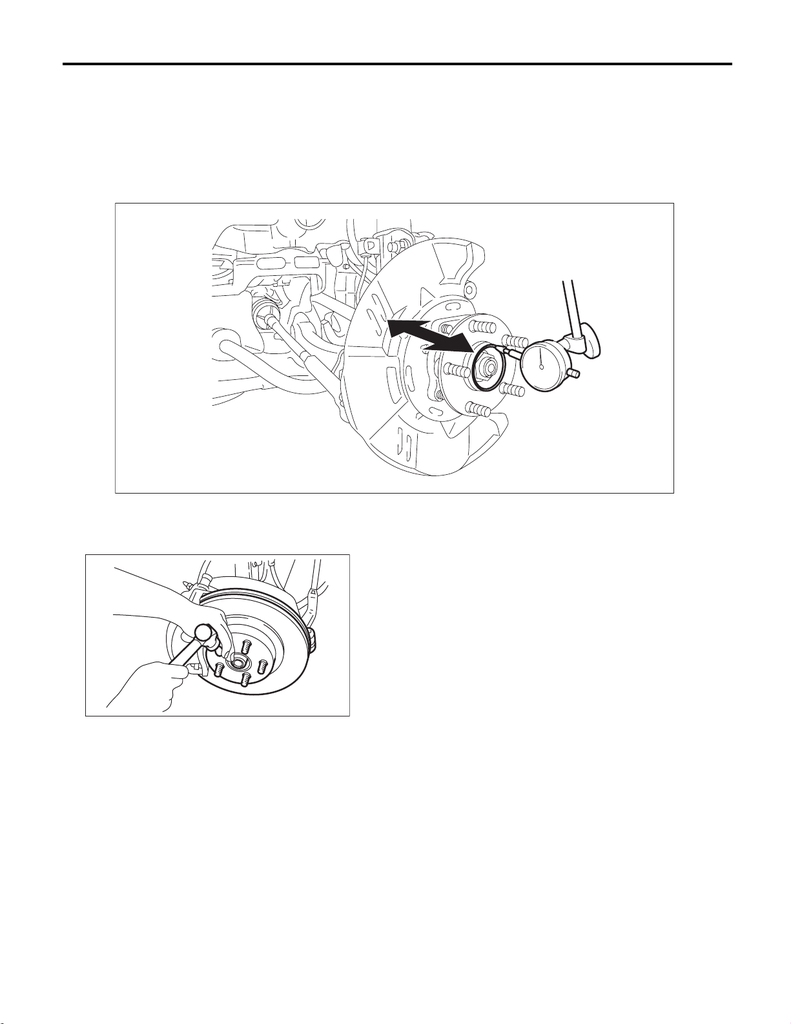

DS-28

Front Hub Unit Bearing

DRIVE SHAFT SYSTEM

7) While depressing the brake pedal, tighten new nuts - axle to the specified torque.

CAUTION:

Do not load the front axle before tightening the nut - axle. Doing so may damage the hub unit COMPL.

Tightening torque:

220 N·m (22.4 kgf-m, 162.3 ft-lb)

8) Inspect the lean of axis direction using a dial gauge. Replace the hub unit COMPL - front axle if the play

exceeds the limit.

Service limit:

Maximum: 0.05 mm (0.0020 in)

9) After tightening the nut - axle, lock it securely.

DS-00493

DS-00048

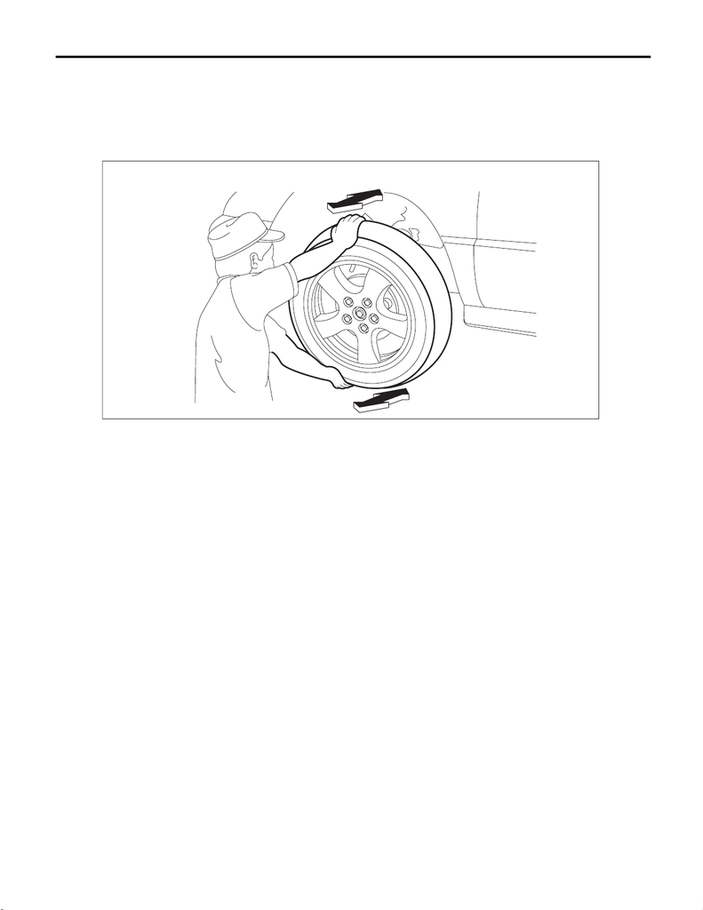

DS-29

Front Hub Unit Bearing

DRIVE SHAFT SYSTEM

10) Install the front wheels, and perform the following inspections.

Tightening torque:

120 N·m (12.2 kgf-m, 88.5 ft-lb)

1. Check the wheels for smooth rotation.

2. Check that there is no play by moving the upper and lower portions of front tire in an axial direction with

the brake pedal released.

• Play exists → Check the hub unit COMPL - front axle. <Ref. to DS-31, INSPECTION, Front Hub Unit

Bearing.>

3. Check that there is no play by moving the upper and lower portions of front tire in an axial direction with

the brake pedal depressed.

• Play exists → Replace the ball joint assembly. <Ref. to FS-33, REMOVAL, Front Ball Joint.>

FS-00510

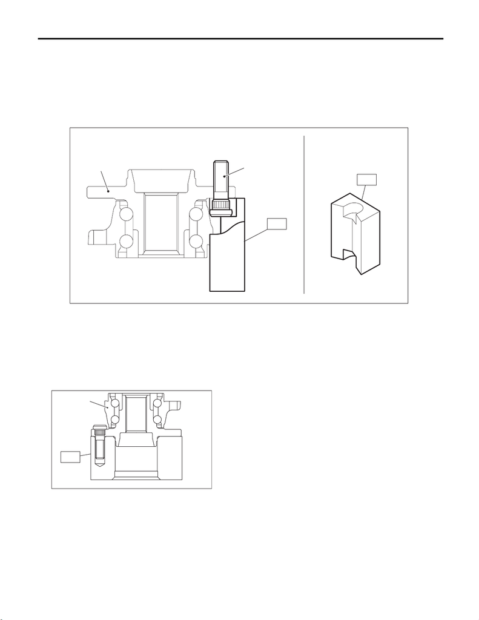

DS-30

Front Hub Unit Bearing

DRIVE SHAFT SYSTEM

C: DISASSEMBLY

Using the ST or a hydraulic press, push out the bolt - hub (b) from the hub unit COMPL - front axle (a).

CAUTION:

• Be careful not to hammer the bolts - hub. This may deform the hub unit COMPL.

• Do not reuse the bolt - hub.

Preparation tool:

ST: HUB STAND (28399AG000)

NOTE:

Since the hub unit COMPL can not be disassembled, only bolts - hub can be removed.

D: ASSEMBLY

1) Install the hub unit COMPL to the ST securely.

Preparation tool:

ST: HUB STAND (28099PA080)

2) Using a press, press new bolts - hub until their seating surfaces contact the hub unit COMPL.

NOTE:

Use the 12 mm (0.47 in) dia. holes in the HUB STAND to prevent bolts from tilting.

DS-00494

ST

(a)

(b)

ST

DS-00253

ST

(1)

(1) Hub unit COMPL - front axle

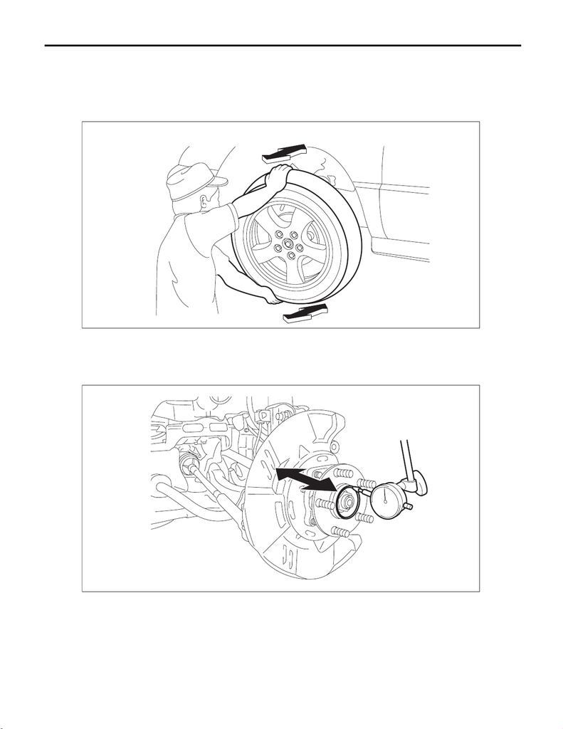

DS-31

Front Hub Unit Bearing

DRIVE SHAFT SYSTEM

E: INSPECTION

1) Moving the front tire up and down by hand, check there is no play in bearing, and check the wheel rotates

smoothly.

CAUTION:

If there is any fault in the bearing, replace the hub unit COMPL.

2) Inspect the lean of axis direction using a dial gauge. Replace the hub unit COMPL if the play exceeds the

limit.

Service limit:

Maximum: 0.05 mm (0.0020 in)

FS-00510

DS-00493